# Cousera Reproducible research week 2

Edwin Wanner

9 oktober 2018

```r
knitr::opts_chunk$set(dev = c('png'), fig.path = 'figure/',echo = TRUE)
```

## Reproducible research - Project 1

This R Markdown document is the report for the Coursera course Reproducible research - week 2. A simple set of data analysis tasks will be performed.

First, reading in the data:

```r
steps <- read.csv("activity.csv")
```

Next, we will transform the date column to be of the type ‘date’.

```r
steps$date <- as.Date(steps$date)
```

## Mean total number of steps per day

In the following tasks, we will ignore the NA.

Calculating the total number of steps taken per day:

```r
stepsPerDay <- aggregate(steps ~ date,data = steps, FUN = sum, na.action = na.omit )
stepsPerDay
```

```
##          date steps
## 1  2012-10-02   126
## 2  2012-10-03 11352
## 3  2012-10-04 12116
## 4  2012-10-05 13294
## 5  2012-10-06 15420
## 6  2012-10-07 11015
## 7  2012-10-09 12811
## 8  2012-10-10  9900
## 9  2012-10-11 10304
## 10 2012-10-12 17382
## 11 2012-10-13 12426
## 12 2012-10-14 15098
## 13 2012-10-15 10139
## 14 2012-10-16 15084
```

[output cut: 39 more lines]

The table shows that that there are missing dates. These are left out on purpose.

To gain more insight into the data, we will create a histogram displaying the total number of steps for each day.

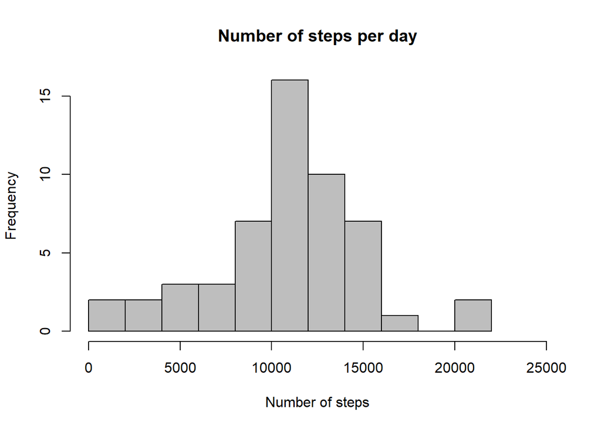

```r
hist(stepsPerDay$steps,
     main = "Number of steps per day",
     xlab = "Number of steps",
     breaks = 10,
     col = "grey",
     xlim = c(0,25000))
```

Now that we know the total number of steps per day, we are now interested in the mean and median number of steps per day.

```r
stepsMean   <- aggregate(steps ~ date,data = steps, FUN = mean, na.action = na.omit )
stepsMedian <- aggregate(steps ~ date,data = steps, FUN = median, na.action = na.omit )
merged <- merge(stepsMean, stepsMedian, by = "date")
names(merged) <- c("date","mean","median")
merged
```

```
##          date       mean median
## 1  2012-10-02  0.4375000      0
## 2  2012-10-03 39.4166667      0
## 3  2012-10-04 42.0694444      0
## 4  2012-10-05 46.1597222      0
## 5  2012-10-06 53.5416667      0
## 6  2012-10-07 38.2465278      0
## 7  2012-10-09 44.4826389      0
## 8  2012-10-10 34.3750000      0
## 9  2012-10-11 35.7777778      0
## 10 2012-10-12 60.3541667      0
## 11 2012-10-13 43.1458333      0
## 12 2012-10-14 52.4236111      0
## 13 2012-10-15 35.2048611      0
## 14 2012-10-16 52.3750000      0
```

[output cut: 39 more lines]

The table clearly shows that the mean is known everywhere, though the median is zero.

## Average daily activity pattern

We will dive deeper into the number of steps, by looking at the 5-minute intervals.

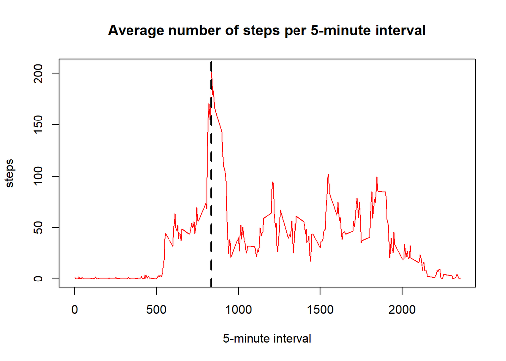

```r
stepsPerInterval <- aggregate(steps~interval, data = steps, FUN = mean, na.action = na.omit)
with(stepsPerInterval, plot(interval, steps, type = "l", col = "red", xlab = "5-minute interval", main = "Average number of steps per 5-minute interval"))

maxInterval <- stepsPerInterval[which.max(stepsPerInterval$steps),1]
abline(v= maxInterval, lwd = 3, lty = 2)
```

The interval that has, on average, the highest number of steps is 835.

## Imputing missing values

We know that there are missing values in the data set.

```r
missing <- sum(is.na(steps$steps))
```

The total number of NA values in the data set is 2304.

In order to fill in the missing values, we will use the average 5-minute intervals to replace the missing values.

```r
idNA <- which(is.na(steps$steps))
stepsFilled <- steps
for( i in 1:length(idNA)) {
        stepsFilled[idNA[i],1] <- stepsPerInterval[which(stepsPerInterval$interval == steps[idNA[i],3]),2]
}
```

Using the dataset without the missing values, the histogram of the total number of steps will look as follows:

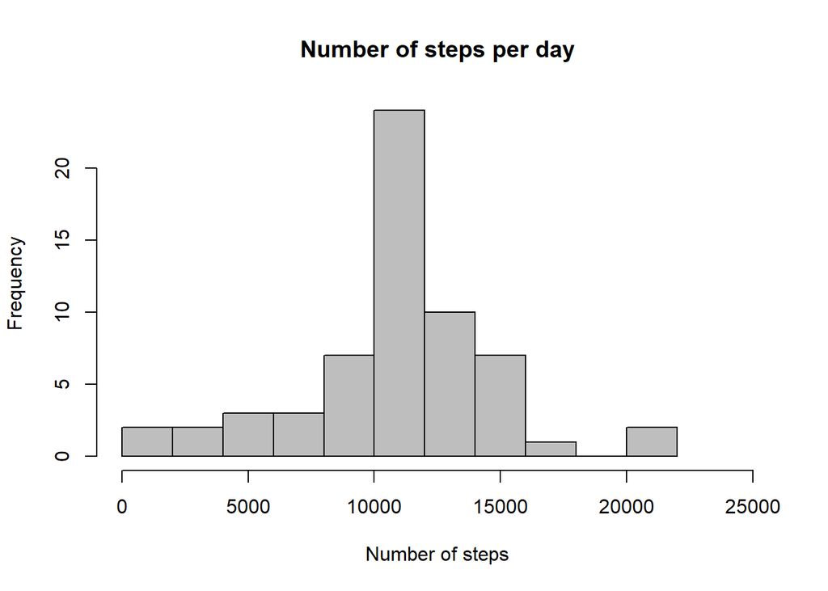

```r
stepsPerDayFilled <- aggregate(steps ~ date,data = stepsFilled, FUN = sum, na.action = na.omit )
hist(stepsPerDayFilled$steps,
     main = "Number of steps per day",
     xlab = "Number of steps",
     breaks = 10,
     col = "grey",
     xlim = c(0,25000))
```

The mean and median are then as follows:

```r
stepsFilledMean   <- aggregate(steps ~ date,data = stepsFilled, FUN = mean, na.action = na.omit )
stepsFilledMedian <- aggregate(steps ~ date,data = stepsFilled, FUN = median, na.action = na.omit )
mergedFilled <- merge(stepsFilledMean, stepsFilledMedian, by = "date")
names(mergedFilled) <- c("date","mean","median")
mergedFilled
```

```
##          date       mean   median
## 1  2012-10-01 37.3825996 34.11321
## 2  2012-10-02  0.4375000  0.00000
## 3  2012-10-03 39.4166667  0.00000
## 4  2012-10-04 42.0694444  0.00000
## 5  2012-10-05 46.1597222  0.00000
## 6  2012-10-06 53.5416667  0.00000
## 7  2012-10-07 38.2465278  0.00000
## 8  2012-10-08 37.3825996 34.11321
## 9  2012-10-09 44.4826389  0.00000
## 10 2012-10-10 34.3750000  0.00000
## 11 2012-10-11 35.7777778  0.00000
## 12 2012-10-12 60.3541667  0.00000
## 13 2012-10-13 43.1458333  0.00000
## 14 2012-10-14 52.4236111  0.00000
```

[output cut: 47 more lines]

We can clearly see some differences in the median, which is not always zero. Furthermore, the dates that had a ‘NA’ value, are now shown, which were ignored in the previous table. The impact of of filling in the missing values is that all days are now shown and not only a selection. The pattern in the histogram is similar, but the frequency is higher.

## differences in activity pattern between weekdays and weekends

There might be a difference in the activity pattern between weekdays and the weekends. In order to investigate this, a new variable will be created that displays whether the given date is a weekday or a weekend.

```r
Sys.setlocale("LC_ALL","English")
```

```
## [1] "LC_COLLATE=English_United States.1252;LC_CTYPE=English_United States.1252;LC_MONETARY=English_United States.1252;LC_NUMERIC=C;LC_TIME=English_United States.1252"
```

```r
stepsFilled$Weekday <- weekdays(stepsFilled$date)
stepsFilled$daytype <- as.factor(ifelse(stepsFilled$Weekday %in% c("Saturday","Sunday"), "Weekend","Weekday"))
```

The panel plot below shows a time series plot of the 5-minute interval average number of steps on weekdays and weekends.

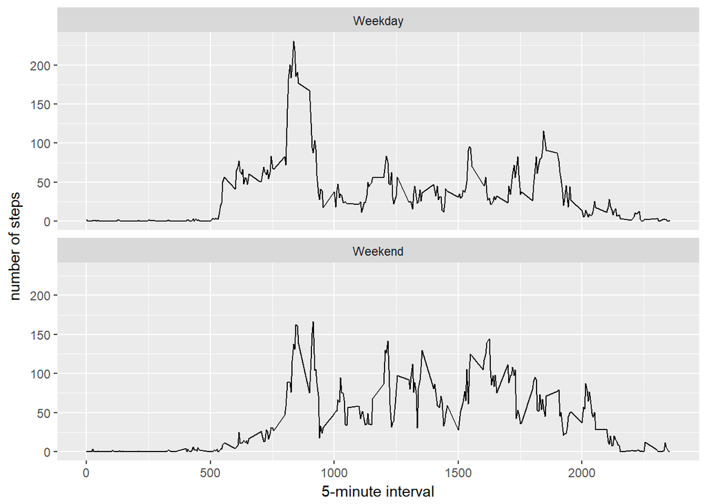

```r
library(ggplot2)
par(mfrow = c(1,2))
stepsIntervalDaytype <- aggregate(steps~interval+daytype, data = stepsFilled, FUN = mean, na.action = na.omit)
ggplot(stepsIntervalDaytype, aes(interval, steps,daytype)) +
        geom_line() +
        facet_wrap(~daytype, ncol =1) +
        labs(y = "number of steps", x = "5-minute interval")
```

The plot for the weekday shows a high peek at the start of the day. In the weekends the average number of steps has more peeks.